# Modeling frameworks

PCB 6455 / BSC 4933: Biometry | Lecture 2

Dr. Brian Maitner

## Today’s agenda

1. Why not just run a correlation?
2. Choosing a model: what it is for, and how it is built
3. One curve, two stories: mechanistic and phenomenological
4. Where variability comes from
5. Setting up R, RStudio, Git and GitHub

Type and run on a code block: type it into your script and run it.  
Run once, in the console: setup you do once per computer, not part of a script.

# Why not just run a correlation?

## Reef fish and their predators

Reef fish in the Caribbean. You have **population counts through time**, and **underwater video of predator visits**.

**Question:** does living at high density make a fish more likely to be eaten?

How would you test this, based on what you already know?

**Challenges to deal with:**

**Correlation** assumes bivariate normal data.

**Regression** assumes a linear relationship and normal errors.

**Mortality counts are neither,** and there were lots of zeros.

## What Sandin and Pacala (2005) did instead

They **wrote the model down directly**:

| Mortality | Model |
| --- | --- |
| absolute | r₀ + r₁n |
| per capita | (r₀ + r₁n) / n |

with binomial and Poisson variation instead of normal.

The answer is **predator visits per hour per additional prey individual**: a number with **ecological units**, not just a p-value or a slope on transformed data.

A model written from the biology gives answers with biological meaning, not just a verdict of “significant”.

## Learning to model

“I want to learn how to model” is **too broad to act on**. Compare “I want to learn genetics”: population structure? Gene expression? Phylogenetics?

Which question are you actually asking?

**This course covers one kind:** statistical modeling, leaning mechanistic. There are lots of other modeling frameworks, and sometimes they can be combined.

## What you should already know

| Area | Enough is |
| --- | --- |
| Statistics | basic familiarity (one undergraduate semester) |
| Computers | beyond point-and-click |
| Math | rusty calculus is fine |
| Ecology | the basics: growth, functional responses |

**Which is rustiest for you?** The book lists remedial reading for each.

We will often **cover things more than once**: to see why the details matter you need the big picture, and to grasp the big picture you need some details. The repetition also helps long-term memory.

# Choosing a model

## Scope and approach: what is the model for?

**Before the table:** what model choices did the reading mention?

| abstract ↔︎ concrete | strategic ↔︎ tactical | general ↔︎ specific |
| --- | --- | --- |
| theoretical ↔︎ applied | qualitative ↔︎ quantitative | descriptive ↔︎ predictive |
| mathematical ↔︎ statistical | mechanistic ↔︎ phenomenological | pattern ↔︎ process |

**Generality has a price.**

**Theoretical:** general and oversimplified; used for qualitative predictions.

**Applied:** messier and more specific; better forecasts, but needs more data.

Adapted from Bolker (2008), Table 1.1

## Technical details: how is it built?

| analytical ↔︎ computational | dynamic ↔︎ static | continuous ↔︎ discrete |
| --- | --- | --- |
| population-based ↔︎ individual-based | deterministic ↔︎ stochastic |  |

|  | Dynamic | Static |
| --- | --- | --- |
| Usually | mathematical models | statistical models |
| What it says | today’s state feeds tomorrow’s | the relationship is fixed |

Combining the two is hard (Bolker chapter 11). This course is mostly static.

Adapted from Bolker (2008), Table 1.1

## Simple is not crude

**Simple ↔︎ complex:** how long is the description? **Crude ↔︎ sophisticated:** how much depth is hidden in it?

|  | Description | Depth |
| --- | --- | --- |
| Flipping virtual coins, one at a time | simple | crude |
| `rbinom()` | simple | sophisticated |
| A random walk | simpler still | more sophisticated |

Sophisticated tools buy power but cost transparency: you can no longer see every step.

Adapted from Bolker (2008), Table 1.1

## Why are there so many options?

**Trade-offs:** models differ in when they are useful.

For example, mechanistic models can be linked to specific mechanisms, **but** may require more data.

You will have to weigh these trade-offs when you choose methods for your own data.

# One curve, two stories

## A shape you’ve seen before

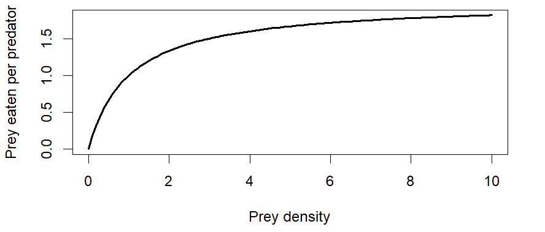

Describe it in words. Where else have you seen this shape?

## Two ways to end up here

**A.** I needed a curve that starts at zero, rises, then flattens. This one does.

**B.** A predator can only handle so many prey per hour.

Which is **mechanistic**, and which is **phenomenological**?

## One curve, two ways to write it

**Mechanistic:** Holling type II

$$f(x) = \frac{\alpha\,x}{1 + \alpha\,h\,x}$$

$\alpha$ is the attack rate; $h$ is the handling time.

**Phenomenological:** Michaelis-Menten form

$$f(x) = \frac{a\,x}{b + x}$$

$a$ is the maximum; $b$ is the half-saturation point, where $f(x) = a/2$.

**The same curve**, when $a = 1/h$ and $b = 1/(\alpha\,h)$.

The same curve can be mechanistic or phenomenological: what decides it is why you chose it, and so which parameters you write down.

## Why does it matter?

| You chose the curve for | So you can |
| --- | --- |
| its **shape** | *describe* your data |
| its **mechanism** | talk about the *process*, *extrapolate further*, and be wrong in a specific, testable way |

# Where variability comes from

## Two parts to every model

| Part | What it describes |
| --- | --- |
| **Deterministic** | the expected pattern: the predictable core relationship, written as a formula |
| **Stochastic** | how the observations scatter around it: the unpredictable variation |

We’ve just done the first part. **Where does the scatter come from?**

Every model has a pattern and a scatter around it, and both are choices.

## Three kinds of randomness

| Kind | Where it comes from | For example |
| --- | --- | --- |
| **Measurement error** | imperfect observation; instruments have limits. Almost always present | a tape read to the nearest cm |
| **Demographic** | different outcomes by chance alone. Matters most in small populations | 20 identical tadpoles, one predator: a different number eaten each time |
| **Environmental** | outside the system: climate, season, topography. Only the unpredictable part | a wet year and a dry year |

## Process vs. measurement

**Process variability** = demographic + environmental. It changes what happens next in the system. **Measurement error** does not.

| A plot has 12 seedlings | Measurement error | Process error |
| --- | --- | --- |
| What happens | you miscount and record 9 | a deer eats 3 |
| Recount next week | 12 | 9, and 9 forever |

Process variation changes the system; measurement error only changes what you write down.

## Your turn: sort the randomness

Measurement, demographic, or environmental?

1. Two observers, same transect, different counts
2. A hurricane kills a seedling cohort
3. 50 tagged fish: 12 survive, then 15
4. A thermometer reads 0.4 °C higher than true
5. Seedlings differ with small-scale light

**Then, in pairs:** think of one question you’d like to ask in your own system. What kind of model could address it: theoretical or applied, mechanistic or phenomenological, deterministic or stochastic?

# Setting up your software

## What we’re installing

| Software | Where | Who |
| --- | --- | --- |
| R | https://www.r-project.org/ | everyone |
| RStudio | https://posit.co/download/rstudio-desktop/ | everyone |
| Git | https://git-scm.com/downloads | grad students; optional for undergrads |
| A GitHub account | https://github.com/ | grad students; optional for undergrads |

Install R before RStudio.

## R

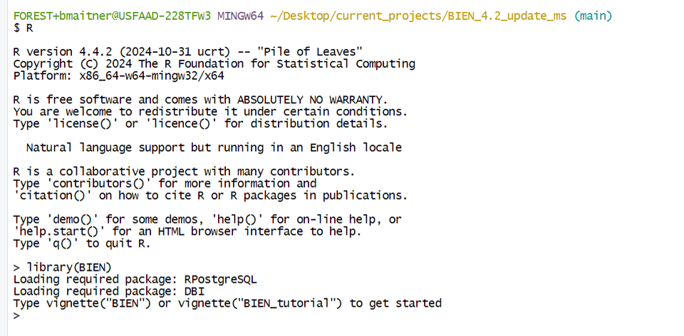

## RStudio

[figure not shown]

## RStudio

[figure not shown]

## RStudio

[figure not shown]

## Write code in a script, not the console

**File > New File > R Script** opens one in the top left. Type there, then run a line, or a selection, with **Ctrl+Enter** (Cmd+Enter on a Mac).

```r
# my first script
seedlings <- c(12, 9, 15)
mean(seedlings)
```

**Check:** 12. Save it with **Ctrl+S** (Cmd+S).

The console is a scratchpad for quick checks; the script is the record of your work, which you can rerun, fix and hand in.

## Git and GitHub

**Git** tracks changes in files. No more multiple versions of a file: you can always go back.

It records what was added or removed in each version, and lets several people work on the same files and combine their changes.

**GitHub** stores Git repositories online, can be used to edit files, and can even run analyses for you

[figure not shown]

## Why use GitHub?

| For you | For others |
| --- | --- |
| a secure backup, in case your computer dies | collaboration |
| easier when you use more than one computer | transparency and reproducibility, if you make it public |
|  | they can use your code (forking and copying) |
|  | it can be archived and cited, for example through Zenodo |

Increasingly expected of biologists.

**Grad students have to; undergrads get extra credit.**

## Tell Git who you are

```r
install.packages(c("usethis", "gitcreds"))

usethis::use_git_config(
  user.name  = "Your Name",
  user.email = "your GitHub email"
)
```

Your name and email are attached to every change you save with Git. Use the email your GitHub account uses.

## Restart RStudio

**Quit RStudio completely, and open it again.** RStudio only looks for Git when it starts, so if Git was installed while RStudio was open, it does not know Git is there yet.

Then open **Tools → Global Options → Git/SVN** and check two things:

The **Git executable** box shows a path (Windows: `C:/Program Files/Git/bin/git.exe`).

**Enable version control interface for RStudio projects** is ticked.

No Git tab yet? That’s expected: it appears once you open a project that Git tracks, which is the next few steps.

## Make your first repository

**Go to your GitHub page and make a new repo**

[figure not shown]

## Copy its address

**Copy the URL**

[figure not shown]

## Bring it into RStudio

In RStudio:

1. **File > New Project…**
2. Select **Version Control**, then **Git**
3. Paste the copied URL into **Repository URL**
4. Pick a folder for it to be created in
5. **Create Project**

This is **cloning**: a copy of the repository on your computer, still linked to GitHub.

## Did it work? A Git tab

The project opens, and a **Git** tab appears in the top right:

[figure not shown]

## If something’s wrong

| Problem | Try |
| --- | --- |
| No Git tab | **Tools → Global Options → Git/SVN.** Is the Git executable found? Restart RStudio after changing it. Then reopen the project |
| “Git not found” | restart RStudio, then restart the computer |
| Windows: packages won’t build | install Rtools |
| Mac: packages won’t build | in Terminal, `xcode-select --install` |
| Still stuck | flag me down |

## Send a change back

1. Open `README.md` from the Files pane, change a line, save
2. In the **Git** tab, tick the file, then **Commit**, and write a short message
3. **Push** (the green up arrow)

The first push asks who you are: **a browser window opens to sign in to GitHub**. Approve it, and the push finishes. Refresh your repo on GitHub to see the change.

## If push asks for a password instead

GitHub stopped accepting account passwords for Git in 2021. Use a **token**:

```r
usethis::create_github_token()   # opens GitHub with the right boxes ticked
gitcreds::gitcreds_set()         # paste the token when asked: once per computer
usethis::git_sitrep()            # checks everything at once
```

Name the token, generate it, and copy it straight away: GitHub shows it once.

**Treat a token like a password.** Never put one in a script, and never commit one.

## Two repositories

**Your GitHub repo:** where your assignments will live. Keep it public, or make it private and give me access.

**The course repo:** lectures, scripts, data, at github.com/bmaitner/biometry_course. Browse it online, or pull everything with Git (Lecture 5).

For grad students: one repo per paper or thesis chapter usually works well.

## Which tool, when

| Tool | What it is | You’ll use it to |
| --- | --- | --- |
| R | the language that runs your code | everything |
| RStudio | where you write and run R | write scripts, see plots and help |
| An R script | a file of code, top to bottom | keep a record you can rerun and hand in |
| Git | tracks every version of your files | go back, see what changed |
| GitHub | your repositories, online | back up, share, hand in assignments |

## Before next class

Read Bolker **1.4 to 1.6**

Next class: discuss 1.4 to 1.6, then work through the examples in 1.7 together

May be a quiz.